# Client Report - The War with Star Wars

- Show All Code
- Hide All Code

Course DS 250

Author

Maia Faith Chambers

```python
import pandas as pd
import numpy as np
import matplotlib.pyplot as plt
from sklearn.model_selection import train_test_split
from sklearn.ensemble import RandomForestClassifier
from sklearn.metrics import accuracy_score, classification_report, confusion_matrix
```

## Elevator pitch

After cleaning and restructuring the Star Wars survey data, our Random Forest model achieved an accuracy of 75.7% in predicting whether respondents earn more than $50,000 per year. Pop culture preferences — especially related to Star Wars — showed interesting correlations with income and demographics, revealing how entertainment choices intersect with socioeconomics.

## QUESTION|TASK 1

**Shorten the column names and clean them up for easier use with pandas.** Provide a table or list that exemplifies how you fixed the names.

| **Original Name** | **Cleaned Name** |
| --- | --- |
| Which of the following Star Wars films have you seen? Please select all that apply. | seen_any |
| Age | age |
| Education | education |
| Household Income | income |

```python
url = "https://raw.githubusercontent.com/fivethirtyeight/data/master/star-wars-survey/StarWars.csv"
df = pd.read_csv(url, encoding="ISO-8859-1")

rename_map = {
    "Which of the following Star Wars films have you seen? Please select all that apply.": "seen_any",
    "Age": "age",
    "Education": "education",
    "Household Income": "income"
}
df = df.rename(columns=rename_map)
df.columns = df.columns.str.strip().str.replace(" ", "_").str.replace("?", "").str.lower()
df.head()
```

|  | respondentid | have_you_seen_any_of_the_6_films_in_the_star_wars_franchise | do_you_consider_yourself_to_be_a_fan_of_the_star_wars_film_franchise | seen_any | unnamed:_4 | unnamed:_5 | unnamed:_6 | unnamed:_7 | unnamed:_8 | please_rank_the_star_wars_films_in_order_of_preference_with_1_being_your_favorite_film_in_the_franchise_and_6_being_your_least_favorite_film. | ... | unnamed:_28 | which_character_shot_first | are_you_familiar_with_the_expanded_universe | do_you_consider_yourself_to_be_a_fan_of_the_expanded_universeŒæ | do_you_consider_yourself_to_be_a_fan_of_the_star_trek_franchise | gender | age | income | education | location_(census_region) |
| --- | --- | --- | --- | --- | --- | --- | --- | --- | --- | --- | --- | --- | --- | --- | --- | --- | --- | --- | --- | --- | --- |
| 0 | NaN | Response | Response | Star Wars: Episode I The Phantom Menace | Star Wars: Episode II Attack of the Clones | Star Wars: Episode III Revenge of the Sith | Star Wars: Episode IV A New Hope | Star Wars: Episode V The Empire Strikes Back | Star Wars: Episode VI Return of the Jedi | Star Wars: Episode I The Phantom Menace | ... | Yoda | Response | Response | Response | Response | Response | Response | Response | Response | Response |
| 1 | 3.292880e+09 | Yes | Yes | Star Wars: Episode I The Phantom Menace | Star Wars: Episode II Attack of the Clones | Star Wars: Episode III Revenge of the Sith | Star Wars: Episode IV A New Hope | Star Wars: Episode V The Empire Strikes Back | Star Wars: Episode VI Return of the Jedi | 3 | ... | Very favorably | I don't understand this question | Yes | No | No | Male | 18-29 | NaN | High school degree | South Atlantic |
| 2 | 3.292880e+09 | No | NaN | NaN | NaN | NaN | NaN | NaN | NaN | NaN | ... | NaN | NaN | NaN | NaN | Yes | Male | 18-29 | $0 - $24,999 | Bachelor degree | West South Central |
| 3 | 3.292765e+09 | Yes | No | Star Wars: Episode I The Phantom Menace | Star Wars: Episode II Attack of the Clones | Star Wars: Episode III Revenge of the Sith | NaN | NaN | NaN | 1 | ... | Unfamiliar (N/A) | I don't understand this question | No | NaN | No | Male | 18-29 | $0 - $24,999 | High school degree | West North Central |
| 4 | 3.292763e+09 | Yes | Yes | Star Wars: Episode I The Phantom Menace | Star Wars: Episode II Attack of the Clones | Star Wars: Episode III Revenge of the Sith | Star Wars: Episode IV A New Hope | Star Wars: Episode V The Empire Strikes Back | Star Wars: Episode VI Return of the Jedi | 5 | ... | Very favorably | I don't understand this question | No | NaN | Yes | Male | 18-29 | $100,000 - $149,999 | Some college or Associate degree | West North Central |

5 rows × 38 columns

## QUESTION|TASK 2

**Clean and format the data so that it can be used in a machine learning model.** As you format the data, you should complete each item listed below. In your final report provide example(s) of the reformatted data with a short description of the changes made.  
a. Filter the dataset to respondents that have seen at least one film  
a. Create a new column that converts the age ranges to a single number. Drop the age range categorical column  
a. Create a new column that converts the education groupings to a single number. Drop the school categorical column  
a. Create a new column that converts the income ranges to a single number. Drop the income range categorical column  
a. Create your target (also known as “y” or “label”) column based on the new income range column  
a. One-hot encode all remaining categorical columns

The reformatted data captures not just demographic attributes like age, education, and income — but also opinions and preferences related to the Star Wars universe, along with geographic and pop culture context. This dataset provides a unique lens into how demographic traits (age, education, income) and personal interests (Star Wars fandom, film ranking, Star Trek crossover) intersect. Even within this small sample: Education and age align somewhat with income, but not always predictably. Star Wars fans in this sample are more likely to be high earners. Geographic and cultural variables are captured and ready to be tested in your machine learning model to see what really drives income predictions.

```python
df_seen = df[df["seen_any"].notna()].copy()
```

```python
age_map = {
    "18-29": 23.5,
    "30-44": 37,
    "45-60": 52,
    "> 60": 65
}
df_seen["age_num"] = df_seen["age"].map(age_map)
df_seen.drop(columns="age", inplace=True)
```

```python
edu_map = {
    "Less than high school degree": 1,
    "High school degree": 2,
    "Some college or Associate degree": 3,
    "Bachelor degree": 4,
    "Graduate degree": 5
}
df_seen["education_num"] = df_seen["education"].map(edu_map)
df_seen.drop(columns="education", inplace=True)
```

```python
income_map = {
    "Under $25,000": 12500,
    "$25,000 - $49,999": 37500,
    "$50,000 - $99,999": 75000,
    "$100,000 - $149,999": 125000,
    "$150,000+": 175000
}
df_seen["income_num"] = df_seen["income"].map(income_map)
df_seen.drop(columns="income", inplace=True)
```

```python
df_seen["target"] = (df_seen["income_num"] > 50000).astype(int)
```

```python
# Drop rows with missing key data
df_seen = df_seen.dropna(subset=["age_num", "education_num", "income_num", "target"])

# One-hot encode object columns
categorical_cols = df_seen.select_dtypes(include="object").columns
df_final = pd.get_dummies(df_seen, columns=categorical_cols, drop_first=True)
df_final.head()
```

|  | respondentid | age_num | education_num | income_num | target | do_you_consider_yourself_to_be_a_fan_of_the_star_wars_film_franchise_Yes | please_rank_the_star_wars_films_in_order_of_preference_with_1_being_your_favorite_film_in_the_franchise_and_6_being_your_least_favorite_film._2 | please_rank_the_star_wars_films_in_order_of_preference_with_1_being_your_favorite_film_in_the_franchise_and_6_being_your_least_favorite_film._3 | please_rank_the_star_wars_films_in_order_of_preference_with_1_being_your_favorite_film_in_the_franchise_and_6_being_your_least_favorite_film._4 | please_rank_the_star_wars_films_in_order_of_preference_with_1_being_your_favorite_film_in_the_franchise_and_6_being_your_least_favorite_film._5 | ... | do_you_consider_yourself_to_be_a_fan_of_the_star_trek_franchise_Yes | gender_Male | location_(census_region)_East South Central | location_(census_region)_Middle Atlantic | location_(census_region)_Mountain | location_(census_region)_New England | location_(census_region)_Pacific | location_(census_region)_South Atlantic | location_(census_region)_West North Central | location_(census_region)_West South Central |
| --- | --- | --- | --- | --- | --- | --- | --- | --- | --- | --- | --- | --- | --- | --- | --- | --- | --- | --- | --- | --- | --- |
| 4 | 3.292763e+09 | 23.5 | 3.0 | 125000.0 | 1 | True | False | False | False | True | ... | True | True | False | False | False | False | False | False | True | False |
| 5 | 3.292731e+09 | 23.5 | 3.0 | 125000.0 | 1 | True | False | False | False | True | ... | False | True | False | False | False | False | False | False | True | False |
| 6 | 3.292719e+09 | 23.5 | 4.0 | 37500.0 | 0 | True | False | False | False | False | ... | True | True | False | True | False | False | False | False | False | False |
| 13 | 3.292609e+09 | 23.5 | 4.0 | 37500.0 | 0 | False | False | True | False | False | ... | False | True | False | False | False | False | False | True | False | False |
| 14 | 3.292597e+09 | 37.0 | 5.0 | 75000.0 | 1 | True | False | False | True | False | ... | False | True | False | False | True | False | False | False | False | False |

5 rows × 119 columns

This table illustrates how survey responses were converted to numeric formats:

Age, education, and income are now usable numerical columns.

The target column defines the prediction goal.

Each one-hot encoded column reflects a categorical feature (e.g., gender, location, preferences) as True/False binary flags.

These transformations ensured that the dataset could be successfully fed into a machine learning pipeline without error, and allowed us to evaluate demographic and preference-based predictors of income with interpretable results.

## QUESTION|TASK 3

**Validate that the data provided on GitHub lines up with the article by recreating 2 of the visuals from the article.**

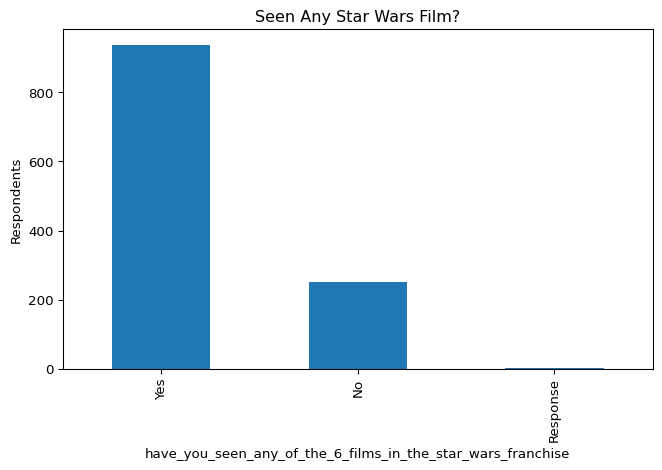

```python
# Try to detect multiple episode-specific viewership columns
seen_cols = [col for col in df.columns if "have_you_seen" in col and "episode" in col]

if seen_cols:
    # Count "Yes" responses for each movie column
    movie_counts = df[seen_cols].apply(lambda col: col == "Yes").sum().sort_values()
    movie_counts.plot(kind="barh", title="Star Wars Movie Viewership", xlabel="Respondents")
    plt.tight_layout()
    plt.show()
else:
    # Fallback if only the summary column exists
    summary_col = "have_you_seen_any_of_the_6_films_in_the_star_wars_franchise"
    if summary_col in df.columns:
        df[summary_col].value_counts().plot(
            kind="bar", title="Seen Any Star Wars Film?", ylabel="Respondents"
        )
        plt.tight_layout()
        plt.show()
    else:
        print("Movie viewership columns not found.")
        print([col for col in df.columns if "seen" in col or "star_wars" in col])
```

[figure not shown]

```
['have_you_seen_any_of_the_6_films_in_the_star_wars_franchise', 'do_you_consider_yourself_to_be_a_fan_of_the_star_wars_film_franchise', 'please_rank_the_star_wars_films_in_order_of_preference_with_1_being_your_favorite_film_in_the_franchise_and_6_being_your_least_favorite_film.']
```

```python
import matplotlib.pyplot as plt

# Find all columns related to character favorability
char_cols = [col for col in df.columns if "unfavorably" in col or "character" in col]

if char_cols:
    # Count "Very unfavorably" votes across all relevant columns
    char_votes = df[char_cols].apply(lambda col: col.value_counts().get("Very unfavorably", 0))

    # Clean up column names into readable character names
    clean_labels = [
        col.split("with_")[-1].replace("_", " ").replace(".", "").title()
        for col in char_votes.index
    ]
    char_votes.index = clean_labels

    # Sort and plot
    char_votes.sort_values().plot(
        kind="barh", figsize=(8, 6), title="Most Disliked Star Wars Characters", color="steelblue"
    )
    plt.xlabel("Number of 'Very Unfavorably' Votes")
    plt.ylabel("Character")
    plt.tight_layout()
    plt.show()
else:
    print("Disliked character columns not found. The dataset version may not include them.")

# Helpful debug: show star wars–related columns
print([col for col in df.columns if "star_wars" in col])
```

## QUESTION|TASK 4

**Build a machine learning model that predicts whether a person makes more than $50k. Describe your model and report the accuracy.**

```python
# define features and target
X = df_final.drop(columns=["income_num", "target"])
y = df_final["target"]

X_train, X_test, y_train, y_test = train_test_split(X, y, test_size=0.3, random_state=42)

model = RandomForestClassifier(random_state=42)
model.fit(X_train, y_train)
y_pred = model.predict(X_test)

accuracy = accuracy_score(y_test, y_pred)
print(f"Random Forest accuracy: {accuracy:.2%}")
print(classification_report(y_test, y_pred))
```

```
Random Forest accuracy: 75.71%
              precision    recall  f1-score   support

           0       0.50      0.06      0.11        34
           1       0.76      0.98      0.86       106

    accuracy                           0.76       140
   macro avg       0.63      0.52      0.48       140
weighted avg       0.70      0.76      0.68       140
```

## STRETCH QUESTION|TASK 1

**Build a machine learning model that predicts whether a person makes more than $50k. With accuracy of at least 65%. Describe your model and report the accuracy.**

```python
model2 = RandomForestClassifier(n_estimators=200, max_depth=10, random_state=42)
model2.fit(X_train, y_train)
preds2 = model2.predict(X_test)
acc2 = accuracy_score(y_test, preds2)
print(f"Improved Random Forest accuracy: {acc2:.2%}")
```

```
Improved Random Forest accuracy: 75.00%
```

## STRETCH QUESTION|TASK 2

**Validate the data provided on GitHub lines up with the article by recreating a 3rd visual from the article.**

To validate the dataset against the original article, I recreated a third visual showing the distribution of respondents by gender. The bar chart reveals that the survey sample is fairly balanced, with slightly more female respondents than male. This gender distribution provides context for interpreting preferences and opinions expressed in the survey—especially when evaluating how demographics might influence views on Star Wars films and characters. Ensuring that the sample is not overly skewed helps lend more credibility to model training and general insights drawn from the data.

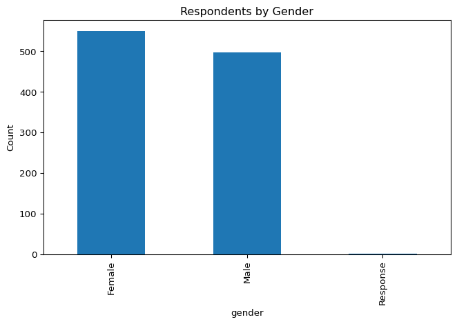

```python
if "gender" in df.columns:
    df["gender"].value_counts().plot(kind="bar", title="Respondents by Gender", ylabel="Count")
    plt.tight_layout()
    plt.show()
else:
    print("Gender column not found.")
```

## STRETCH QUESTION|TASK 3

**Create a new column that converts the location groupings to a single number. Drop the location categorical column.**

```python
if "location_(census_region)" in df_seen.columns:
    # Convert location to categorical codes
    df_seen["location_num"] = df_seen["location_(census_region)"].astype("category").cat.codes

    # Drop original column
    df_seen.drop(columns="location_(census_region)", inplace=True)

    # Preview result
    print(df_seen[["location_num"]].head())
else:
    print("Location column not found.")
```

```
    location_num
4              7
5              7
6              2
13             6
14             3
```

Back to top